# COMP47590: Advanced Machine Learning

# Assignment 1: Pneumonia Detection

Name(s): Vishal Padma

Student Number(s): 19200174

```python
import keras.backend as K
from keras.models import Model, Sequential
from keras.layers import Input, Dense, Flatten, Dropout, BatchNormalization
from keras.layers import Conv2D, SeparableConv2D, MaxPooling2D,AveragePooling2D, LeakyReLU, Activation
from keras.optimizers import Adam
from keras.preprocessing.image import ImageDataGenerator
from keras.callbacks import ModelCheckpoint, ReduceLROnPlateau, EarlyStopping
import tensorflow as tf
import keras
from sklearn import linear_model

import sklearn
from sklearn.tree import export_graphviz
from sklearn import metrics
from sklearn.model_selection import GridSearchCV
from sklearn.model_selection import cross_val_score
from sklearn.model_selection import train_test_split
from sklearn import preprocessing
from sklearn.utils import shuffle
from sklearn import linear_model

from IPython.display import SVG

import csv
import os
import cv2
import random
import numpy as np
import pandas as pd
import matplotlib.pyplot as plt
%matplotlib inline
import scipy as sp
import PIL
```

# Task 1: Data Loading and Exploration

## Step1: Loaded the chest xray images and displayed some.

Here i have kept the folder containing all the images in the C drive and mentioned the path to it as seen below.

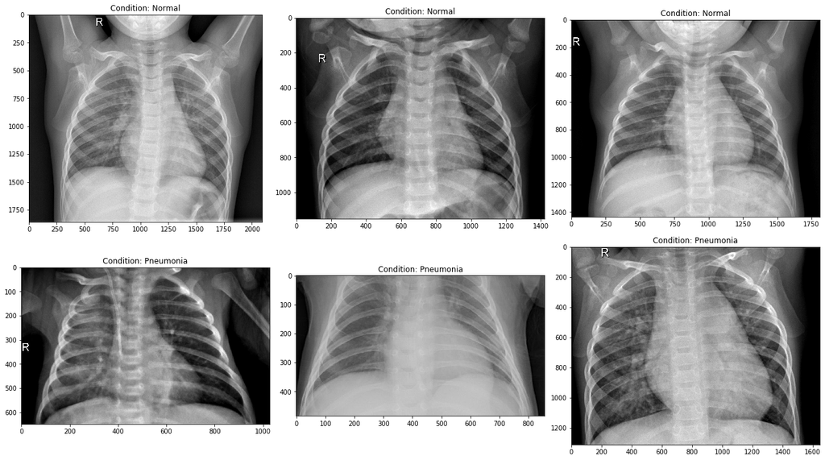

```python
Input_1 = 'C:/Users/LENOVO/Assignment_2_ML/chest_xray_small/'

fig,A = plt.subplots(2, 3, figsize=(18, 10))
A = A.ravel()
plt.tight_layout()

for i, file in enumerate(['train']):
    path = Input_1+file
    for i in range(3):
        A[i].imshow(plt.imread(path+'/NORMAL/'+os.listdir(path+'/NORMAL')[i]), cmap='gray')
        A[i].set_title('Condition: Normal'.format(file))
        A[i+3].imshow(plt.imread(path+'/PNEUMONIA/'+os.listdir(path+'/PNEUMONIA')[i]), cmap='gray')
        A[i+3].set_title('Condition: Pneumonia'.format(file))
```

# Step 2: Tunring the imagies into vector form

```python
# assuming data is contained in a train and a validation set
Train_data_dir = Input_1+'train/'

# Set up some parmaeters for data loading
sample_rate = 1.0

# desired dimensions of our images.
img_width, img_height = 168, 128

# different backends (e.g. tensorflow and theano) use different orderings for image data
if K.image_data_format() == 'channels_first':
     input_shape = (3, img_width, img_height)
else:
     input_shape = (img_width, img_height, 3)

#for gray scaled data making the channel equal to 1.
if K.image_data_format() == 'channels_first':
    input_shape_grey = (1, img_width, img_height)
else:
    input_shape_grey = (img_width, img_height, 1)

Training_class_folders = [i for i in os.listdir(Train_data_dir) if not (i.startswith('.') or i.startswith('Icon'))]
num_classes = len(Training_class_folders)

# Initialise arrays for data storage
X_data = np.ndarray((0, input_shape[0], input_shape[1], input_shape[2]), dtype=np.float)
X_data_grey = np.ndarray((0, input_shape_grey[0], input_shape_grey[1], input_shape_grey[2]), dtype=np.float)
Y_data= np.ndarray(0, dtype=np.str)


for i, file in enumerate(['train']):
    path = Input_1+file
    for i, classes in enumerate(['NORMAL', 'PNEUMONIA']):
        print('Processing images of class {}'.format(classes))
        Class_folder = path + "/" + classes + "/"
        # generate filenames from the data folder and do sampling
        Img_name = [Class_folder+i for i in os.listdir(Class_folder) if not i.startswith('.')] # use this for full dataset
        Img_name = random.sample(Img_name, int(len(Img_name)*sample_rate))

        # Create a data array for image data
        count = len(Img_name)
        X_data_part = np.ndarray((count, input_shape[0], input_shape[1], input_shape[2]), dtype=np.float)
        X_data_grey_part = np.ndarray((count, input_shape_grey[0], input_shape_grey[1], input_shape_grey[2]), dtype=np.float)
        # Iterate throuigh the filenames and for each one load the image, resize and normalise
        for i, image_file in enumerate(Img_name):
            # Low the images and resize them
            image = cv2.imread(image_file, cv2.IMREAD_COLOR)
            image = cv2.resize(image, (img_height, img_width), interpolation=cv2.INTER_CUBIC)
            image = image[:,:,[2,1,0]] # OpenCV and matplotlib use differnet channel oerderings so fix this

            image_grey = cv2.cvtColor(image, cv2.COLOR_BGR2GRAY)
            image_grey = cv2.resize(image_grey, (img_height, img_width), interpolation=cv2.INTER_CUBIC)
            #grayscale has no channel, but convolutions need 4D array thus keeing the channel as 1
            image_grey = np.asarray(image_grey).reshape(image_grey.shape[0],image_grey.shape[1],1)
            #image = image[:,:,0] # OpenCV and matplotlib use differnet channel orderings so fix this

            # If channel order of network does not match open cv format swap it
            if K.image_data_format() == 'channels_first':
                image=np.swapaxes(np.swapaxes(image, 1, 2), 0, 1)

            # Add image data to data array and normalise
            X_data_part[i] = image
            X_data_part[i] = X_data_part[i]/255

            X_data_grey_part[i] = image_grey
            X_data_grey_part[i] = X_data_grey_part[i]/255

            # Add label to label array
            Y_data = np.append(Y_data, classes)

        if i%100 == 0: print('Processed {} of {} for class {} '.format(i, count, classes))

        print('Processed {} of {} for class {} '.format(i + 1, count, classes))

        # Append the part to the overall data array
        X_data = np.append(X_data, X_data_part, axis=0)
        X_data_grey = np.append(X_data_grey, X_data_grey_part, axis=0)


print("Data shape: {}".format(X_data.shape))
```

```
Processing images of class NORMAL
Processed 153 of 153 for class NORMAL
Processing images of class PNEUMONIA
Processed 76 of 76 for class PNEUMONIA
Data shape: (229, 168, 128, 3)
```

## Spliting the data into Test and Train Data

```python
# Perfrom split to train, validation, test
X_train, X_test, y_train, y_test = train_test_split(X_data_grey, Y_data, random_state=0, test_size = 0.30, train_size = 0.7)
X_train_color, X_test_color, y_train_color, y_test_color = train_test_split(X_data, Y_data, random_state=0, test_size = 0.30, train_size = 0.7)
```

```python
X_train.shape
```

## Step 3: Binary vector conversion

```python
# Convert class vectors to binary class matrices.
y_train_encoder = sklearn.preprocessing.LabelEncoder()
y_train_num = y_train_encoder.fit_transform(y_train)
y_train_wide = keras.utils.to_categorical(y_train_num, num_classes)

y_test_num = y_train_encoder.fit_transform(y_test)
y_test_wide = keras.utils.to_categorical(y_test_num, num_classes)

# Convert class vectors to binary class matrices. For original images
y_train_encoder_color = sklearn.preprocessing.LabelEncoder()
y_train_num_color = y_train_encoder.fit_transform(y_train_color)
y_train_wide_color = keras.utils.to_categorical(y_train_num_color, num_classes)

y_test_num_color = y_train_encoder.fit_transform(y_test_color)
y_test_wide_color = keras.utils.to_categorical(y_test_num_color, num_classes)
```

```python
classes_num_label = dict()

for idx, lbl in enumerate(y_train_encoder.classes_):
    classes_num_label[idx] = lbl
```

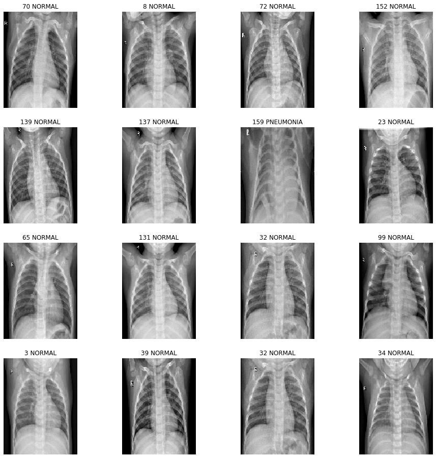

```python
pltsize=4
row_images = 4
col_images = 4
plt.figure(figsize=(col_images*pltsize, row_images*pltsize))

for i in range(row_images * col_images):
    i_rand = random.randint(0, X_train.shape[0])
    plt.subplot(row_images,col_images,i+1)
    plt.axis('off')
    plt.imshow(PIL.Image.fromarray(((X_data[i_rand]) * 255).astype(np.uint8)))
    plt.title((str(i_rand) + " " + Y_data[i_rand]))
```

## Step 4: Using logistic Regression on the dataset

So to use the Logistic regression we need to convert the test and train set into 2D arrays

```python
B = img_width*img_height*1
X_train_LG=X_train.reshape(X_train.shape[0],B)
X_test_LG=X_test.reshape(X_test.shape[0],B)
```

```python
print(X_train_LG.shape,y_train.shape)
```

```
(160, 21504) (160,)
```

```python
# Do the same job with logistic regression
Model_LR = linear_model.LogisticRegression()
Model_LR.fit(X_train_LG,y_train)
```

```
LogisticRegression(C=1.0, class_weight=None, dual=False, fit_intercept=True,
                   intercept_scaling=1, l1_ratio=None, max_iter=100,
                   multi_class='auto', n_jobs=None, penalty='l2',
                   random_state=None, solver='lbfgs', tol=0.0001, verbose=0,
                   warm_start=False)
```

```python
#Logistic Regression
Model_LR = linear_model.LogisticRegression()
Model_LR.fit(X_train_LG,y_train)
# Make a set of predictions for the training data
y_pred = Model_LR.predict(X_test_LG)

# Print Accuracy details
accuracy = \
metrics.accuracy_score(y_test, y_pred) # , normalize=True, sample_weight=None
print("Accuracy: " +  str(accuracy))

# Print performance details
print(metrics.classification_report(y_test, y_pred))

# Print confusion matrix
print("Confusion Matrix")
pd.crosstab(y_test, y_pred, rownames=['True'], colnames=['Predicted'], margins=True)
```

```
Accuracy: 0.8985507246376812
              precision    recall  f1-score   support

      NORMAL       0.90      0.96      0.93        46
   PNEUMONIA       0.90      0.78      0.84        23

    accuracy                           0.90        69
   macro avg       0.90      0.87      0.88        69
weighted avg       0.90      0.90      0.90        69

Confusion Matrix
```

| Predicted True | NORMAL | PNEUMONIA | All |
| --- | --- | --- | --- |
| NORMAL | 44 | 2 | 46 |
| PNEUMONIA | 5 | 18 | 23 |
| All | 49 | 20 | 69 |

# Step 5: Creating the model for CNN model

```python
#leNet-5 architecture is refered from = "https://medium.com/@mgazar/lenet-5-in-9-lines-of-code-using-keras-ac99294c8086"

Model2 = keras.Sequential()

Model2.add(Conv2D(filters=6, kernel_size=(3, 3), activation='relu', input_shape=input_shape_grey))
Model2.add(AveragePooling2D())

Model2.add(Conv2D(filters=16, kernel_size=(3, 3), activation='relu'))
Model2.add(AveragePooling2D())

Model2.add(Flatten())

Model2.add(Dense(units=120, activation='relu'))

Model2.add(Dense(units=84, activation='relu'))

Model2.add(Dense(units=2, activation = 'softmax'))

# Compile the Model1
Model2.compile(optimizer='adam', loss='binary_crossentropy', metrics=['accuracy'])

Model2.summary()
```

```
Model: "sequential_2"
_________________________________________________________________
Layer (type)                 Output Shape              Param #
=================================================================
conv2d_3 (Conv2D)            (None, 166, 126, 6)       60
_________________________________________________________________
average_pooling2d_1 (Average (None, 83, 63, 6)         0
_________________________________________________________________
conv2d_4 (Conv2D)            (None, 81, 61, 16)        880
_________________________________________________________________
average_pooling2d_2 (Average (None, 40, 30, 16)        0
_________________________________________________________________
flatten_2 (Flatten)          (None, 19200)             0
_________________________________________________________________
dense_3 (Dense)              (None, 120)               2304120
_________________________________________________________________
dense_4 (Dense)              (None, 84)                10164
_________________________________________________________________
dense_5 (Dense)              (None, 2)                 170
=================================================================
Total params: 2,315,394
Trainable params: 2,315,394
Non-trainable params: 0
_________________________________________________________________
```

```python
batch_size=64
epochs=20

# Callbacks
mcp = ModelCheckpoint(filepath='./best_weights.hdf5', save_best_only=True, save_weights_only=True)
lr_reduce = ReduceLROnPlateau(monitor='val_loss', factor=0.3, patience=2, verbose=2, mode='max')
early_stop = EarlyStopping(monitor='val_loss', min_delta=0.1, patience=1, mode='min')

history_CNN = Model2.fit(X_train, y_train_wide,
          batch_size=batch_size,
          epochs=epochs,
          verbose = 1,
          validation_split = 0.2,
          shuffle=True,
          callbacks=[mcp])
```

```
Train on 128 samples, validate on 32 samples
```

## Prediction for the CNN model

```python
# Make a set of predictions for the test data
pred = Model2.predict_classes(X_test)

# Print performance details
print(metrics.classification_report(y_test_num, pred))
print("Confusion matrix")
print(metrics.confusion_matrix(y_test_num, pred))
```

```
              precision    recall  f1-score   support

           0       0.91      0.91      0.91        46
           1       0.83      0.83      0.83        23

    accuracy                           0.88        69
   macro avg       0.87      0.87      0.87        69
weighted avg       0.88      0.88      0.88        69

Confusion matrix
[[42  4]
 [ 4 19]]
```

# Step 6: Perform data augmentation on dataset

Changing different aspects of the image, like brightness and use zoom on the images and shifthing the height range

```python
Train_datagen = ImageDataGenerator(zoom_range=[0.6,1.1],
                    height_shift_range=0.1,
                    width_shift_range=0.1,
                    brightness_range=[0.2,1.0])
```

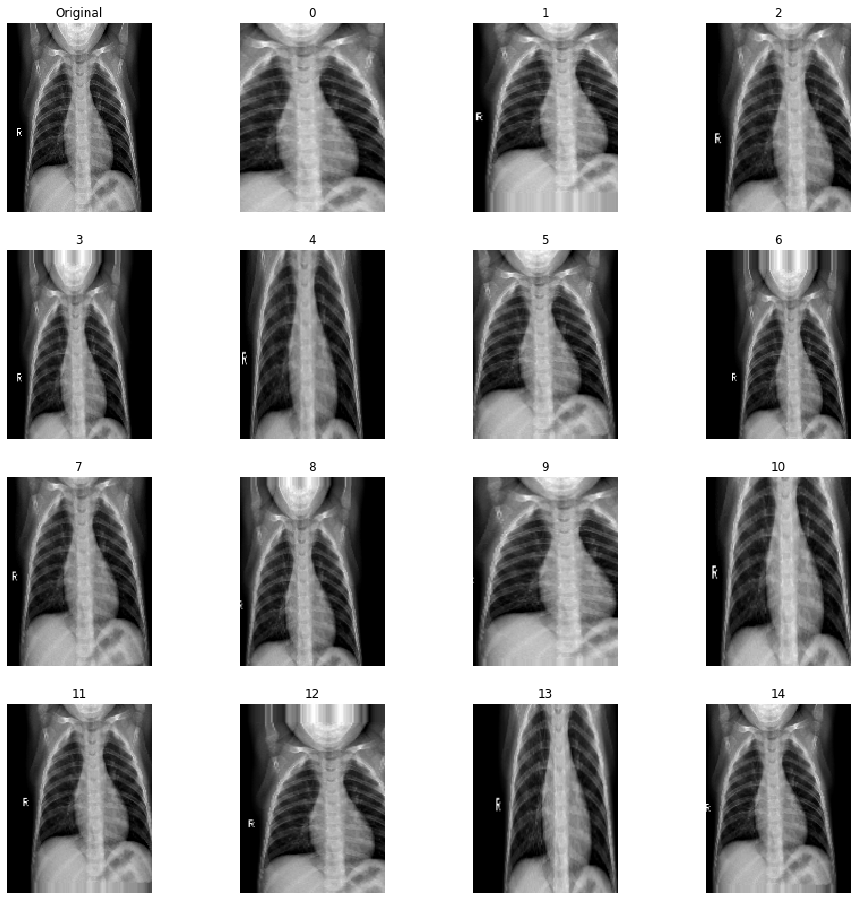

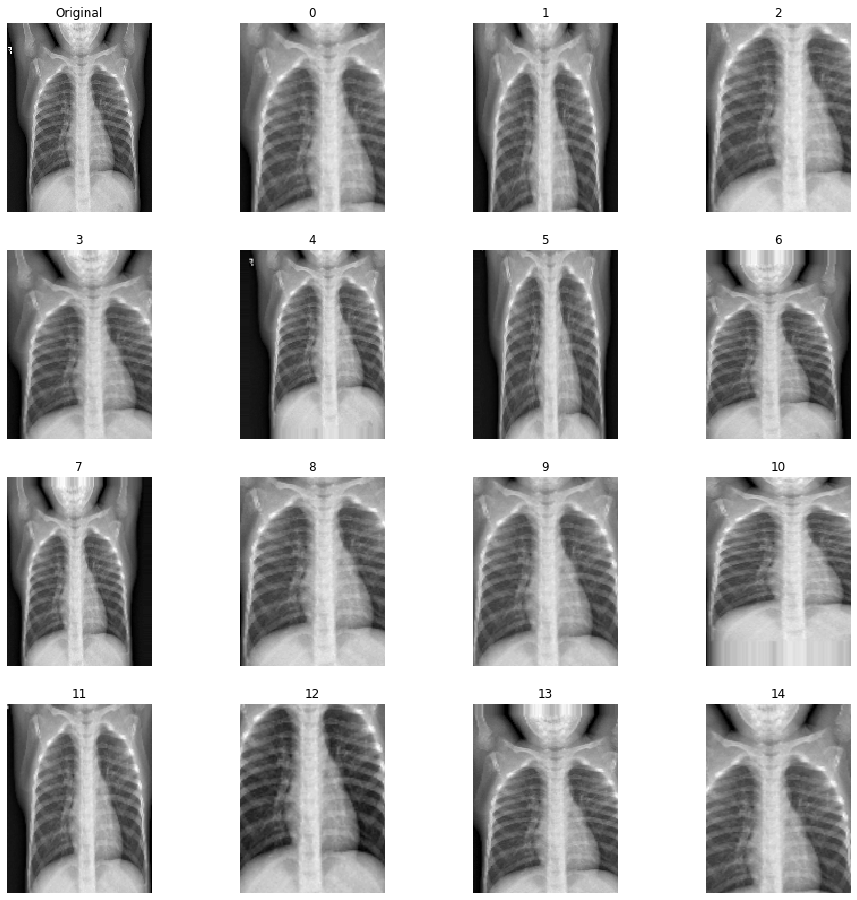

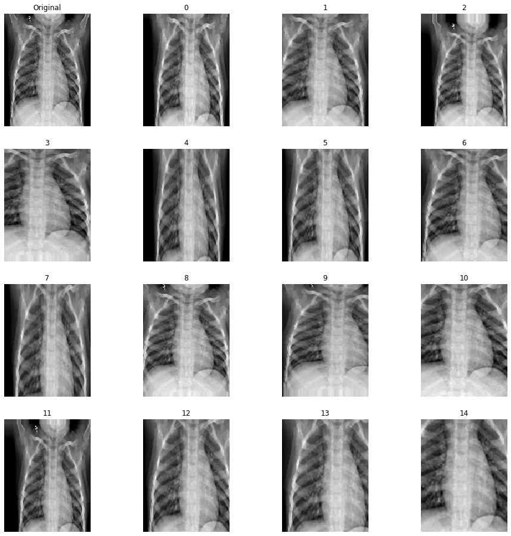

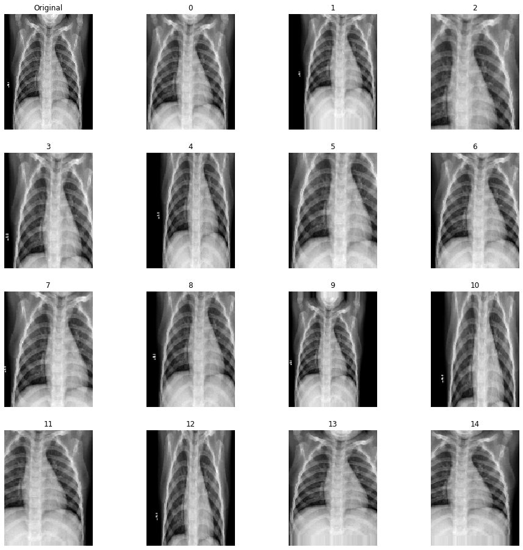

```python
from keras.preprocessing.image import array_to_img

pltsize=4
row_images = 4
col_images = 4

# fit parameters from data
Train_datagen.fit(X_train)

for idx in range(0, 4):
    # Plot the original image
    plt.figure(figsize=(col_images*pltsize, row_images*pltsize))
    plt.subplot(row_images,col_images,1)
    plt.axis('off')
    plt.imshow(array_to_img(X_train[idx]),cmap="gray")
    plt.title("Original")
    #plot the randomly seleted augmentation for the original image
    for i in range(row_images * col_images - 1):
        rand_trans = Train_datagen.random_transform(X_train[idx])
        plt.subplot(row_images,col_images,i+2)
        plt.axis('off')
        plt.imshow(array_to_img(rand_trans),cmap="gray")
        plt.title(i)

    plt.show()
```

```python
import copy
Data_aug_model = copy.deepcopy(Model2)
batch_size = 64
epochs = 20

# Set up the callback to save the best model based on validaion data
best_weights_filepath = './best_weights_notebook22.hdf5'
mcp = ModelCheckpoint(best_weights_filepath, monitor="val_loss",
                      save_best_only=True, save_weights_only=False)

History_DA = Data_aug_model.fit_generator(Train_datagen.flow(X_train, y_train_wide, batch_size=batch_size),
                steps_per_epoch=len(X_train) / batch_size,
                validation_data=(X_test, y_test_wide),
                epochs=epochs,
                verbose = 1,
                shuffle=True,
                callbacks=[mcp])
```

## Predictions for the CNN model after data augmentation

```python
# Make a set of predictions for the test data
pred = Data_aug_model.predict_classes(X_test)

# Print performance details
print(metrics.classification_report(y_test_num, pred))
print("Confusion matrix")
print(metrics.confusion_matrix(y_test_num, pred))
```

```
              precision    recall  f1-score   support

           0       0.67      1.00      0.80        46
           1       0.00      0.00      0.00        23

    accuracy                           0.67        69
   macro avg       0.33      0.50      0.40        69
weighted avg       0.44      0.67      0.53        69

Confusion matrix
[[46  0]
 [23  0]]
```

# Step7: VGG16 Model

```python
#vgg16expects the input with 3 channels thus using the color data
#include_top=false : not to include the 3 fully-connected layers at the top of the network
VGG16_model = keras.applications.VGG16(weights='imagenet', include_top=False, input_shape = X_train_color[0].shape)
display(VGG16_model.summary())
```

```
Model: "vgg16"
_________________________________________________________________
Layer (type)                 Output Shape              Param #
=================================================================
input_2 (InputLayer)         (None, 168, 128, 3)       0
_________________________________________________________________
block1_conv1 (Conv2D)        (None, 168, 128, 64)      1792
_________________________________________________________________
block1_conv2 (Conv2D)        (None, 168, 128, 64)      36928
_________________________________________________________________
block1_pool (MaxPooling2D)   (None, 84, 64, 64)        0
_________________________________________________________________
block2_conv1 (Conv2D)        (None, 84, 64, 128)       73856
_________________________________________________________________
block2_conv2 (Conv2D)        (None, 84, 64, 128)       147584
_________________________________________________________________
block2_pool (MaxPooling2D)   (None, 42, 32, 128)       0
_________________________________________________________________
block3_conv1 (Conv2D)        (None, 42, 32, 256)       295168
_________________________________________________________________
block3_conv2 (Conv2D)        (None, 42, 32, 256)       590080
_________________________________________________________________
block3_conv3 (Conv2D)        (None, 42, 32, 256)       590080
_________________________________________________________________
block3_pool (MaxPooling2D)   (None, 21, 16, 256)       0
_________________________________________________________________
block4_conv1 (Conv2D)        (None, 21, 16, 512)       1180160
_________________________________________________________________
block4_conv2 (Conv2D)        (None, 21, 16, 512)       2359808
_________________________________________________________________
block4_conv3 (Conv2D)        (None, 21, 16, 512)       2359808
_________________________________________________________________
block4_pool (MaxPooling2D)   (None, 10, 8, 512)        0
_________________________________________________________________
block5_conv1 (Conv2D)        (None, 10, 8, 512)        2359808
_________________________________________________________________
block5_conv2 (Conv2D)        (None, 10, 8, 512)        2359808
_________________________________________________________________
block5_conv3 (Conv2D)        (None, 10, 8, 512)        2359808
_________________________________________________________________
block5_pool (MaxPooling2D)   (None, 5, 4, 512)         0
=================================================================
Total params: 14,714,688
Trainable params: 14,714,688
Non-trainable params: 0
_________________________________________________________________
```

```
None
```

```python
VGG16_last_layer = VGG16_model.output

# build a classifier model to put on top of the VGG16 model
A1 = Flatten()(VGG16_last_layer)
A2 = Dense(256, activation='relu')(A1)
A3 = Dropout(0.5)(A2)
final_layer = Dense(num_classes, activation = 'softmax')(A3)

# Assemble the full model out of both parts
FULL_model = keras.Model(VGG16_model.input, final_layer)

# set the first 16 layers (last three conv block before the fully connected layes)
# to non-trainable (weights will not be updated)
for layer in FULL_model.layers[:16]:
    layer.trainable = False

# compile the model with a SGD/momentum optimizer
# and a very slow learning rate.
FULL_model.compile(loss='binary_crossentropy',
              optimizer=keras.optimizers.SGD(lr=1e-4, momentum=0.9),
              metrics=['accuracy'])

FULL_model.summary()
```

```
Model: "model_1"
_________________________________________________________________
Layer (type)                 Output Shape              Param #
=================================================================
input_2 (InputLayer)         (None, 168, 128, 3)       0
_________________________________________________________________
block1_conv1 (Conv2D)        (None, 168, 128, 64)      1792
_________________________________________________________________
block1_conv2 (Conv2D)        (None, 168, 128, 64)      36928
_________________________________________________________________
block1_pool (MaxPooling2D)   (None, 84, 64, 64)        0
_________________________________________________________________
block2_conv1 (Conv2D)        (None, 84, 64, 128)       73856
_________________________________________________________________
block2_conv2 (Conv2D)        (None, 84, 64, 128)       147584
_________________________________________________________________
block2_pool (MaxPooling2D)   (None, 42, 32, 128)       0
_________________________________________________________________
block3_conv1 (Conv2D)        (None, 42, 32, 256)       295168
_________________________________________________________________
block3_conv2 (Conv2D)        (None, 42, 32, 256)       590080
_________________________________________________________________
block3_conv3 (Conv2D)        (None, 42, 32, 256)       590080
_________________________________________________________________
block3_pool (MaxPooling2D)   (None, 21, 16, 256)       0
_________________________________________________________________
block4_conv1 (Conv2D)        (None, 21, 16, 512)       1180160
_________________________________________________________________
block4_conv2 (Conv2D)        (None, 21, 16, 512)       2359808
_________________________________________________________________
block4_conv3 (Conv2D)        (None, 21, 16, 512)       2359808
_________________________________________________________________
block4_pool (MaxPooling2D)   (None, 10, 8, 512)        0
_________________________________________________________________
block5_conv1 (Conv2D)        (None, 10, 8, 512)        2359808
_________________________________________________________________
block5_conv2 (Conv2D)        (None, 10, 8, 512)        2359808
_________________________________________________________________
block5_conv3 (Conv2D)        (None, 10, 8, 512)        2359808
_________________________________________________________________
block5_pool (MaxPooling2D)   (None, 5, 4, 512)         0
_________________________________________________________________
flatten_4 (Flatten)          (None, 10240)             0
_________________________________________________________________
dense_7 (Dense)              (None, 256)               2621696
_________________________________________________________________
dropout_4 (Dropout)          (None, 256)               0
_________________________________________________________________
dense_8 (Dense)              (None, 2)                 514
=================================================================
Total params: 17,336,898
Trainable params: 7,341,826
Non-trainable params: 9,995,072
_________________________________________________________________
```

```python
batch_size = 64
epochs = 20

# Set up the callback to save the best model based on validaion data - notebook 2.2 needs to be run first.
best_weights_filepath = './best_weights_notebook23.hdf5'
mcp = ModelCheckpoint(best_weights_filepath, monitor="val_loss",
                      save_best_only=True, save_weights_only=False)

history = FULL_model.fit(X_train_color, y_train_wide_color,
          batch_size=batch_size,
          epochs=epochs,
          verbose = 1,
          validation_split = 0.2,
          shuffle=True,
          callbacks=[mcp])
```

```
Train on 128 samples, validate on 32 samples
```

## Predictions for VGG16 Model

```python
# Make a set of predictions for the validation data
pred = np.argmax(FULL_model.predict(X_test_color),axis=1)

# Print performance details
print(metrics.classification_report(y_test_num_color, pred))
print("Confusion matrix")
print(metrics.confusion_matrix(y_test_num_color, pred))
```

```
              precision    recall  f1-score   support

           0       0.84      1.00      0.91        46
           1       1.00      0.61      0.76        23

    accuracy                           0.87        69
   macro avg       0.92      0.80      0.83        69
weighted avg       0.89      0.87      0.86        69

Confusion matrix
[[46  0]
 [ 9 14]]
```

# Conclusion

In conclusion i have provided the table below which compares the prediction of CNN model and CNN model after data augmentation and the third model is the VGG16 model. I have used the smaller dataset, i did try with the larger dataset but it was taking two long to process and i had to shift to the smaller dataset. To check which model performs better i have considered in this case is the F1-measure in all three models to comprare the accuracy.

**Below table marks the F1-Measure for the three models**

[output not shown]

So as seen in the table we can see that logistic regression has the best accuracy when compared with all the other models. The ineresting thing to notic here is that when we run the CNN model after data augmentation, there is a decrease in the accuracy/F1-measure. This might be due to the attributes used in the data augmentaion where we change the height, zoom it and rescale it. Maybe the attributes i have used might not suit the x-ray dataset or maybe it is beacuse we changed the x-rays where in the first place we need x-ray as a whole. Maybe doing data augmentation on X-rays images doesnt help.

When VGG16 was model was used the F1-measure is as good as CNN model and we can actually used CNN or VGG16 for the dataset provided when comapared to the predictions after the Data augmentation process. Logistic Regression has the highest F1-measure, so that is also an excellent model to use for the given datatset.

```python
! jupyter nbconvert --to html 19200174_Assignment_AML-Small_Data_Set-Copy1.ipynb
```

```
[NbConvertApp] Converting notebook 19200174_Assignment_AML-Small_Data_Set-Copy1.ipynb to html
[NbConvertApp] Writing 3927785 bytes to 19200174_Assignment_AML-Small_Data_Set-Copy1.html
```